# Pilot experiment - Analysis

This file contains the statistical analysis of the experimental data that we collected in our pilot study that replicates the paper “What makes a word special? Words as unmotivated cues” (Edmiston & Lupyan, 2015)

First we will have a look at the raw data from the pilot study

```r
# read in data from pilot study
df <- read_csv("pilot_study_results.csv")

# look at the dataset
head(df)
```

```
## # A tibble: 6 x 24
##   submission_id    RT   age comments correctness cue_category cue_type education
##           <dbl> <dbl> <dbl> <lgl>    <chr>       <chr>        <chr>    <chr>
## 1          1579  3085    24 NA       correct     bird         sound    <NA>
## 2          1579  3177    24 NA       correct     motorcycle   label    <NA>
## 3          1579  3097    24 NA       correct     bird         sound    <NA>
## 4          1579  1724    24 NA       correct     drum         sound    <NA>
## 5          1579  2396    24 NA       correct     bird         label    <NA>
## 6          1579  2390    24 NA       correct     bird         label    <NA>
## # ... with 16 more variables: endTime <dbl>, expected <chr>,
## #   experiment_id <dbl>, gender <chr>, image_category <chr>, info <chr>,
## #   key_pressed <chr>, languages <chr>, picture <chr>, question <lgl>,
## #   sound <chr>, startDate <chr>, startTime <dbl>, timeSpent <dbl>,
## #   trial_number <dbl>, trial_type <chr>
```

## General information

In total 4 participants took part in our pilot study. The average age of the participants is 40. We use 6 different categories from which there are each two pictures of category subgroup instances. For each of the six categories (*dog, guitar, drum, motor cycle, bird and phone*), there are four pictures. Two of those pictures show instances of one subcategory and two show instances of another subcategory. For example, the category *dog* is represented in four pictures, with two of them showing Miniature Poodles and two showing Labrador mixes.

## Data cleaning and transformation

We will remove the practice data. Also we will only consider the trials where the participants response was correct and the categories were matching (auditory cue category fits the category instance shown at the picture).

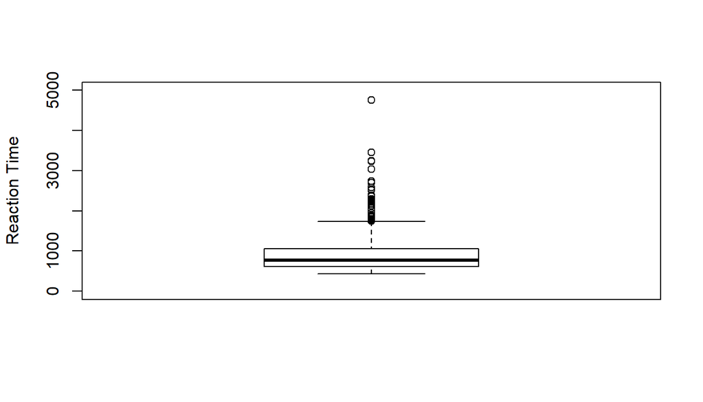

```r
# remove practice trials
df_main <- df[df$trial_type != 'practice',]

# rename column info to trial_info
names(df_main)[names(df_main)=="info"] <- "trial_info"

# To estimate which data points have to be excluded we plot a box plot. Now we take the value of the extreme of the upper whisker as maximum value and the extreme of the lower whisker as minimum value. We will remove data points that are above the max_RT and those that are below the min_RT.
box_RT <- boxplot(df_main$RT, data=df_main, ylim = c(0, 5000), plot=TRUE, ylab = "Reaction Time")
```

```r
min_RT <- box_RT$stats[1]
max_RT <- box_RT$stats[5]

removed <- ((df_main$RT<min_RT) | (df_main$RT>max_RT))
percentage <- sum(removed)/length(df_main$RT)*100
data_clean <- df_main[!removed,]

accuracy <- sum(data_clean$correctness=="correct")/length(data_clean$correctness)

# We use only the trial data where the response was correct and if the categories were matching
data_cor_resp <- data_clean %>%
  filter(correctness == "correct" & expected =="match")
```

We removed 44 trials which is 5.73% of the trials from the data because of too low or to high reaction times (outliers). As explained in the preregistration report, we estimate which data points are excluded via a box plot. The minimum value that we accept is the extreme of the lower whisker. The maximum value that we accept is the extreme of the upper whisker.  
Here y_min: 440 and y_max: 1737.

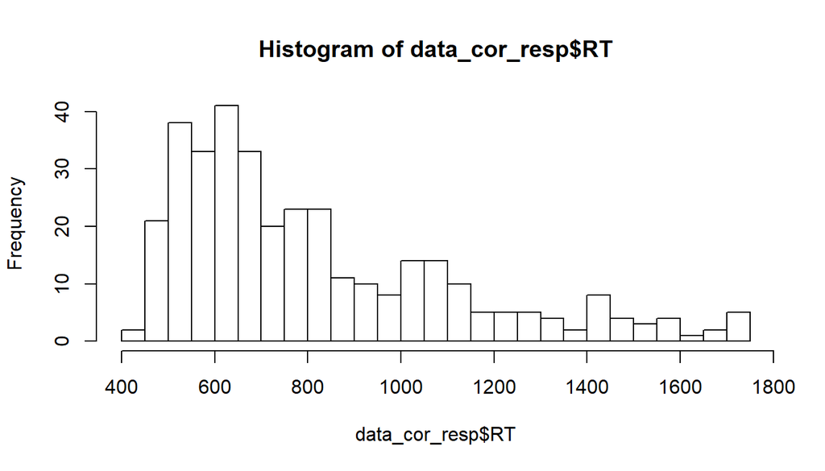

```r
hist(data_cor_resp$RT, breaks = 20) # this shows us a very skewed data, thus we apply a log transformation
```

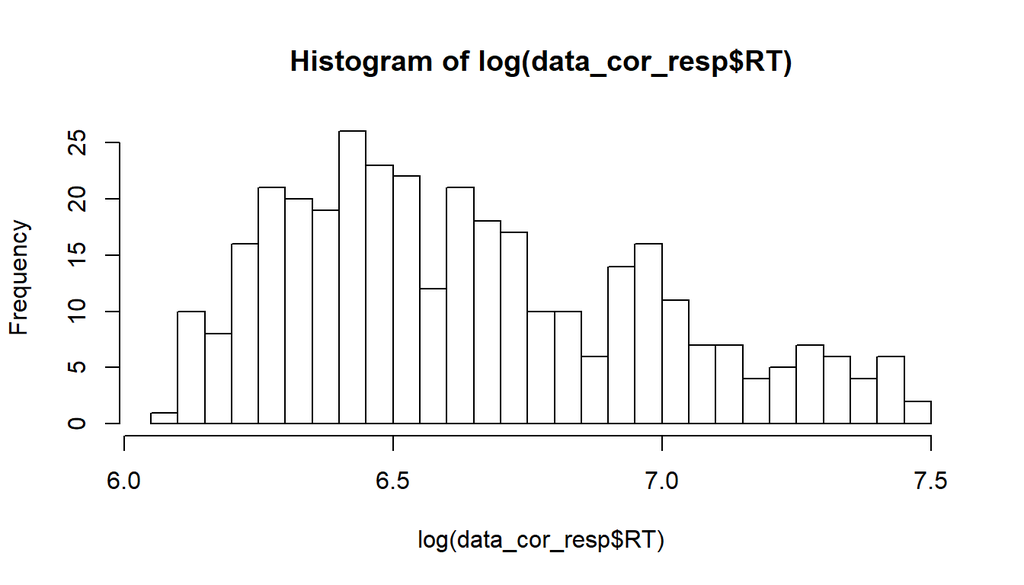

```r
hist(log(data_cor_resp$RT), breaks = 20)
```

```r
data_cor_resp$RT_log <- log(data_cor_resp$RT)
head(data_cor_resp)
```

```
## # A tibble: 6 x 25
##   submission_id    RT   age comments correctness cue_category cue_type education
##           <dbl> <dbl> <dbl> <lgl>    <chr>       <chr>        <chr>    <chr>
## 1          1579  1716    24 NA       correct     phone        sound    <NA>
## 2          1579  1208    24 NA       correct     bird         label    <NA>
## 3          1579  1572    24 NA       correct     motorcycle   label    <NA>
## 4          1579   639    24 NA       correct     guitar       sound    <NA>
## 5          1579   617    24 NA       correct     phone        label    <NA>
## 6          1579  1536    24 NA       correct     motorcycle   sound    <NA>
## # ... with 17 more variables: endTime <dbl>, expected <chr>,
## #   experiment_id <dbl>, gender <chr>, image_category <chr>, trial_info <chr>,
## #   key_pressed <chr>, languages <chr>, picture <chr>, question <lgl>,
## #   sound <chr>, startDate <chr>, startTime <dbl>, timeSpent <dbl>,
## #   trial_number <dbl>, trial_type <chr>, RT_log <dbl>
```

## Overview

Since the pilot study only has a very small number of participants, the data does not represent a distribution of the general population. To get an overview about the pilot data we provide a plot that shows the overall distribution of the reaction time dependent on the trial type (congruent environmental sound, incongruent environmental sound and verbal category label) as well as the standard error that tells us how much the values are deviating from the mean. The jitter plot shows the single data points grouped by the trial type. The data points are color coded for each participant to get an impression of the varying distribution between the subjects. Note that the plotted reaction times are the non-log-transformed reaction time values.

```r
# We calculate the mean and the standard error for each trial type
overall_means <- group_by(data_cor_resp, trial_info) %>% summarise(RT = mean(RT))
overall_errors <- group_by(data_cor_resp, trial_info) %>% summarise(SE = sd(RT)/sqrt(length(RT)))
overall_means$SE <- overall_errors$SE
overall_means
```

```
## # A tibble: 3 x 3
##   trial_info       RT    SE
##   <chr>         <dbl> <dbl>
## 1 congruent      784.  30.7
## 2 incongruent    826.  35.2
## 3 label_correct  827.  22.8
```

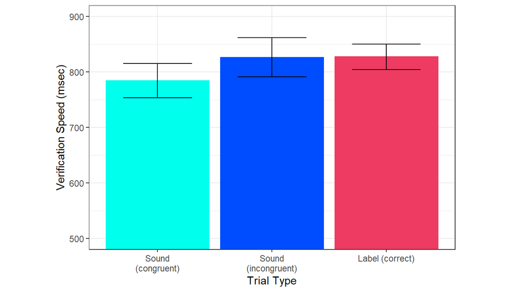

```r
# For the second plot create column where subjects are renamed into characters
data_cor_resp$subjectChar <- ifelse(data_cor_resp$submission_id==1563, "A", ifelse(data_cor_resp$submission_id==1578, "B", ifelse(data_cor_resp$submission_id==1565, "C", "D")))

# plot the overall means and the standard error
pl_colors <- c("#00FFED", "#004CFF", "#ED3B61")
all_points_plot <- ggplot(data_cor_resp, aes(x=trial_info, y=RT)) +     geom_jitter(aes(colour=subjectChar)) +
  labs(x="Trial Type", y= "Verification speed (ms)")

rt_plot <- ggplot(overall_means, aes(x=trial_info, y=RT)) +
  geom_col(color=pl_colors, fill=pl_colors, position=position_dodge()) +
  geom_errorbar(aes(ymin=RT-SE, ymax=RT+SE), width=.6,
                 position=position_dodge(.9)) +
  theme(aspect.ratio = 2/3) +
  coord_cartesian(ylim=c(500,900)) +
  scale_x_discrete('Trial Type', labels=c('Sound\n(congruent)', 'Sound\n(incongruent)', 'Label (correct)')) +
    scale_y_continuous('Verification Speed (msec)')

rt_plot
```

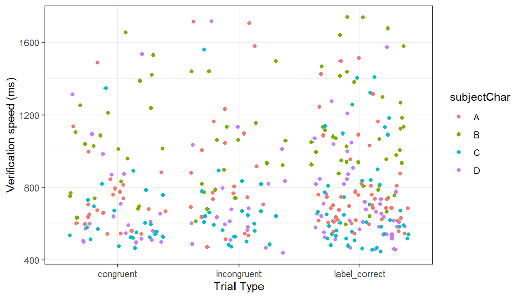

```r
all_points_plot
```

From what we see in the plots it is not clear that the two factors of the experiment (cue_type and sound_type) have an influence on the reaction times. The results of the following analysis will not have enough statistical power to draw a final conclusion. It leads us in a certain direction and helps to test the planned statistical test that we will use for the study.

## Preparation for analysis

We use the simple (contrast) coding scheme to dummy code our factors *cue_type* and *sound_type*, which each have two levels. First we need to calculate the contrast matrix.

```r
# We need a column that says if the sound was incongruent or congruent to the picture and has an NA in the label trials
data_cor_resp$sound_type <- ifelse(data_cor_resp$cue_type=='label', NA, ifelse(data_cor_resp$trial_info=="congruent", 'congruent', 'incongruent'))

data_cor_resp$cue_type <- as.factor(data_cor_resp$cue_type)
data_cor_resp$sound_type <- as.factor(data_cor_resp$sound_type)
contrasts(data_cor_resp$cue_type)
```

```
##       sound
## label     0
## sound     1
```

```r
contrasts(data_cor_resp$sound_type)
```

```
##             incongruent
## congruent             0
## incongruent           1
```

```r
# Prepare data set for analysis

# Applying the dummy coding from above on the two factors sound_type and cue_type
data_cor_resp$sound_type_nr <- ifelse(data_cor_resp$cue_type=='label', NA, ifelse(data_cor_resp$sound_type=="congruent", 0.5, -0.5))
data_cor_resp$cue_type_nr <- ifelse(data_cor_resp$cue_type=='label', -0.5, 0.5)

# We need a column where a unique trial ID is stated, that tells us about what picture/sound exactly it is. This will be included as a random effect in the linear mixed regression model
data_cor_resp$trialID <- paste(substring(data_cor_resp$picture, 18, nchar(data_cor_resp$picture)-4), substring(data_cor_resp$sound, 11, nchar(data_cor_resp$sound)-4), sep=":")

head(data_cor_resp)
```

```
## # A tibble: 6 x 30
##   submission_id    RT   age comments correctness cue_category cue_type education
##           <dbl> <dbl> <dbl> <lgl>    <chr>       <chr>        <fct>    <chr>
## 1          1579  1716    24 NA       correct     phone        sound    <NA>
## 2          1579  1208    24 NA       correct     bird         label    <NA>
## 3          1579  1572    24 NA       correct     motorcycle   label    <NA>
## 4          1579   639    24 NA       correct     guitar       sound    <NA>
## 5          1579   617    24 NA       correct     phone        label    <NA>
## 6          1579  1536    24 NA       correct     motorcycle   sound    <NA>
## # ... with 22 more variables: endTime <dbl>, expected <chr>,
## #   experiment_id <dbl>, gender <chr>, image_category <chr>, trial_info <chr>,
## #   key_pressed <chr>, languages <chr>, picture <chr>, question <lgl>,
## #   sound <chr>, startDate <chr>, startTime <dbl>, timeSpent <dbl>,
## #   trial_number <dbl>, trial_type <chr>, RT_log <dbl>, subjectChar <chr>,
## #   sound_type <fct>, sound_type_nr <dbl>, cue_type_nr <dbl>, trialID <chr>
```

## Hypothesis testing

Recall our two hypothesis:  
1. Environmental sound cues are not as effective as category labels in activating a concept. That is, reaction times for trials with environmental cues are higher than for trials with verbal labels.  
2. Sound cues activate specific category exemplars instead of general categories. That is, reaction times for congruent trials will be lower than for incongruent trials.

In the following analysis we will use linear mixed effects regression models that include our factors of interest as fixed effects (cue_type and sound_type) but also account for random effects, based on recommendations from the paper “Random effects structure for confirmatory hypothesis testing: Keep it maximal” (Barr et. al., 2013). The random effects account for random intercept and random slope effects of within-subject factors, as well as random intercept effects for unique trial types.

```r
# This function is used to compare the complex and the simpler model explained below. The methods used in the analysis we are using are based on and as close as possible to the methods used in the statistical analysis of the original paper.

model_comparison <- function(complex, simple, factor) {
  # First we compute the parameter estimation for the factor of interest
  coeff_complex_model <- summary(complex)$coefficients
  parameter <- coeff_complex_model[factor, 'Estimate']
  std_error <- coeff_complex_model[factor, 'Std. Error']

  # Compare the more complex model with the simple model. We compute the chi-square and the p-value that   we use for statistical inference.
  compare_with_simple <- anova(complex, simple)
  chi_sqr <- compare_with_simple['complex', 'Chisq']
  p_value <- compare_with_simple['complex', 'Pr(>Chisq)']
  report_comparison <- sprintf("Estimated parameter = %.2f ,(Std. Error: %.2f), Chi Sqr(1) = %.2f, p = %.4f", parameter, std_error, chi_sqr, p_value)

  list(report_comparison, compare_with_simple, parameter, std_error, p_value)
}
```

### Testing the first hypothesis

The first model states that if the cue is a verbal label, it leads to faster reaction times than the environmental sound cues. This would mean that verbal labels are more effective than environmental sounds that are produced by instances of the category. It is compared to the simpler model that does not include the factor cue_type. Remember that the cue_type verbal label is coded as -0.5 and the environmental cue_type is coded as 0.5. The coding of the factors let us make assumptions about the direction of the effect of the cue_type on the verification speed (reaction time). If the estimated parameter (computed from the linear mixed effects regression model) for the factor cue_type is positive, we can infer that trials with environmental sound cues lead to higher reaction times than trials with verbal label cues. Recall that the reaction time values RT are log-transformed.

We compare it with the basic model:  
RT ~ 1 + (1|submission_id) + (1|trialID)

Now we investigate if the more complex model that includes the cue_type as a fixed effect fits better than the more simple model, that does not account for an fixed effect of the cue_type (verbal label vs. environmental cue) on the reaction time.

```r
# All the trials that were congruent and the picture was matching auditory label
cuetype <- lmer(RT_log ~ cue_type_nr + (1|submission_id) + (1|trialID), data=data_cor_resp[data_cor_resp$trial_info!='incongruent',])
cuetype.simple <- lmer(RT_log ~ 1 + (1|submission_id) + (1|trialID), data=data_cor_resp[data_cor_resp$trial_info!='incongruent',])
```

```r
# Using the function above to compare the complex and the simple model
results1 <- model_comparison(cuetype, cuetype.simple, "cue_type_nr")

# Now we would like to compute the confidence intervals to see how precise the parameter estimation is and how much it could vary if we would repeat the measurements.
confidence_int <- confint(cuetype, method='Wald', level=0.95)["cue_type_nr", ]
```

Summary of the results of testing for the effects mentioned in hypothesis nr. 1:  
- the parameter estimation for the factor cue_type is: B = -0.06, (Std. Error: 0.04) 95% CI [-0.13, 0.02]  
- the calculated p-value is: 0.1467718

### Testing the second hypothesis

The second model states that if the environmental cue is congruent to the instance of the category subgroup depicted (e.g. hearing a light dog bark followed by the picture of a small dog), leads to faster reaction times than the incongurent environmental sound cues (e.g. hearing a dark dog bark followed by the picture of a small dog). Based on the original paper we hypothesize that sound cues activate specific category exemplars instead of general categories. That is, reaction times for congruent trials will be lower than for incongruent trials.The complex model including the sound_type as factor of interest is compared to the simpler model that does not include the factor sound_type. The sound_type congruent is coded as 0.5 and the incongruent sound_type is coded as -0.5. According to the coding of the factor level congruent and incongruent we can state that congruent sound trials lead to lower reaction times, if the estimated parameter (computed from our more complex linear mixed effects regression model) for the factor sound_type is negative.

For hypothesis 2 we fit the model:  
RT ~ sound_type + (1+sound_type | participantID) + (1 | trialID)

We compare it with the simpler model that does not include the factor sound_type  
RT ~ 1 + (1| participantID) + (1 | trialID)

Now we investigate if the more complex model that includes the sound_type as a fixed effect fits better than the more simple model, that does not account for an fixed effect of the sound_type (congruent vs incongruent) on the reaction time.

```r
soundtype <- lmer(RT_log ~ sound_type_nr + (1+sound_type_nr|submission_id) + (1|trialID), data=data_cor_resp[data_cor_resp$cue_type == 'sound',])
soundtype.simple <- lmer(RT_log ~ 1 + (1|submission_id) + (1|trialID), data=data_cor_resp[data_cor_resp$cue_type == 'sound',])
```

```r
# Using the function above to compare the complex and the simple model
results2 <- model_comparison(soundtype, soundtype.simple, "sound_type_nr")

# Now we would like to compute the confidence intervals to see how precise the parameter estimation is and how much it could vary if we would repeat the measurements.
confidence_int2 <- confint(soundtype, method='Wald', level=0.95)["sound_type_nr", ]
```

Since we only have a very small sample size, the results do not let us make a reliable conclusion about the effect of the factors. For more reliable inference we will collect more participants in the follow-up study.

## Exploratory analysis

```r
# Function to plot the posteriors
plot_posterior <- function(model, data, plot_title) {
  pp_data <- posterior_predict(model, nsamples = 50)
color_scheme_set("gray" )
plot_dense <- ppc_dens_overlay(y = data, yrep = pp_data) +
  labs(x = "Reaction Time (log transformed)", title = plot_title) +
  theme(title = element_text(size=10))
  plot_dense
}
```

So now we will first fit the two complex models with brm, that computes a bayesian regression model. Then we will plot the posterior distribution and see how close they are to the underlying distribution.

```r
fit_cue_type <- brm(RT_log ~ cue_type + (1+cue_type|submission_id) + (1|trialID), data_cor_resp[data_cor_resp$trial_info != 'incongruent',], control = list(adapt_delta = 0.99), seed=1001)
fit_cue_type
```

```
##  Family: gaussian
##   Links: mu = identity; sigma = identity
## Formula: RT_log ~ cue_type + (1 + cue_type | submission_id) + (1 | trialID)
##    Data: data_cor_resp[data_cor_resp$trial_info != "incongr (Number of observations: 267)
## Samples: 4 chains, each with iter = 2000; warmup = 1000; thin = 1;
##          total post-warmup samples = 4000
##
## Group-Level Effects:
## ~submission_id (Number of levels: 4)
##                              Estimate Est.Error l-95% CI u-95% CI Rhat Bulk_ESS
## sd(Intercept)                    0.41      0.31     0.13     1.26 1.00     1415
## sd(cue_typesound)                0.09      0.14     0.00     0.42 1.00     1695
## cor(Intercept,cue_typesound)     0.05      0.59    -0.94     0.97 1.00     4330
##                              Tail_ESS
## sd(Intercept)                    1752
## sd(cue_typesound)                1583
## cor(Intercept,cue_typesound)     2753
##
## ~trialID (Number of levels: 72)
##               Estimate Est.Error l-95% CI u-95% CI Rhat Bulk_ESS Tail_ESS
## sd(Intercept)     0.05      0.03     0.00     0.11 1.00     1149     1900
##
## Population-Level Effects:
##               Estimate Est.Error l-95% CI u-95% CI Rhat Bulk_ESS Tail_ESS
## Intercept         6.67      0.24     6.20     7.16 1.00     1660     1653
## cue_typesound    -0.05      0.08    -0.19     0.10 1.00     2151     1528
##
## Family Specific Parameters:
##       Estimate Est.Error l-95% CI u-95% CI Rhat Bulk_ESS Tail_ESS
## sigma     0.29      0.01     0.26     0.32 1.00     5032     2496
##
## Samples were drawn using sampling(NUTS). For each parameter, Bulk_ESS
## and Tail_ESS are effective sample size measures, and Rhat is the potential
## scale reduction factor on split chains (at convergence, Rhat = 1).
```

```r
fit_sound_type <- brm(RT_log ~ sound_type + (1+sound_type|submission_id) + (1|trialID), data_cor_resp[data_cor_resp$cue_type == 'sound',], control = list(adapt_delta = 0.99), seed=1002)
fit_cue_type
```

```
##  Family: gaussian
##   Links: mu = identity; sigma = identity
## Formula: RT_log ~ cue_type + (1 + cue_type | submission_id) + (1 | trialID)
##    Data: data_cor_resp[data_cor_resp$trial_info != "incongr (Number of observations: 267)
## Samples: 4 chains, each with iter = 2000; warmup = 1000; thin = 1;
##          total post-warmup samples = 4000
##
## Group-Level Effects:
## ~submission_id (Number of levels: 4)
##                              Estimate Est.Error l-95% CI u-95% CI Rhat Bulk_ESS
## sd(Intercept)                    0.41      0.31     0.13     1.26 1.00     1415
## sd(cue_typesound)                0.09      0.14     0.00     0.42 1.00     1695
## cor(Intercept,cue_typesound)     0.05      0.59    -0.94     0.97 1.00     4330
##                              Tail_ESS
## sd(Intercept)                    1752
## sd(cue_typesound)                1583
## cor(Intercept,cue_typesound)     2753
##
## ~trialID (Number of levels: 72)
##               Estimate Est.Error l-95% CI u-95% CI Rhat Bulk_ESS Tail_ESS
## sd(Intercept)     0.05      0.03     0.00     0.11 1.00     1149     1900
##
## Population-Level Effects:
##               Estimate Est.Error l-95% CI u-95% CI Rhat Bulk_ESS Tail_ESS
## Intercept         6.67      0.24     6.20     7.16 1.00     1660     1653
## cue_typesound    -0.05      0.08    -0.19     0.10 1.00     2151     1528
##
## Family Specific Parameters:
##       Estimate Est.Error l-95% CI u-95% CI Rhat Bulk_ESS Tail_ESS
## sigma     0.29      0.01     0.26     0.32 1.00     5032     2496
##
## Samples were drawn using sampling(NUTS). For each parameter, Bulk_ESS
## and Tail_ESS are effective sample size measures, and Rhat is the potential
## scale reduction factor on split chains (at convergence, Rhat = 1).
```

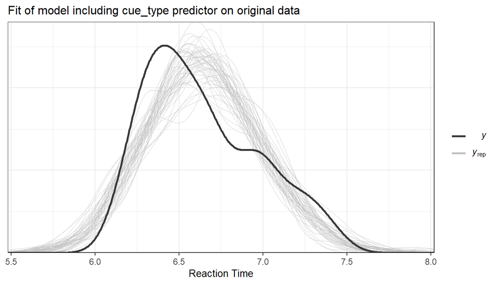

```r
plot_posterior(fit_cue_type, data_cor_resp[data_cor_resp$trial_info != 'incongruent',]$RT_log, "Fit of model including cue_type predictor on original data")
```

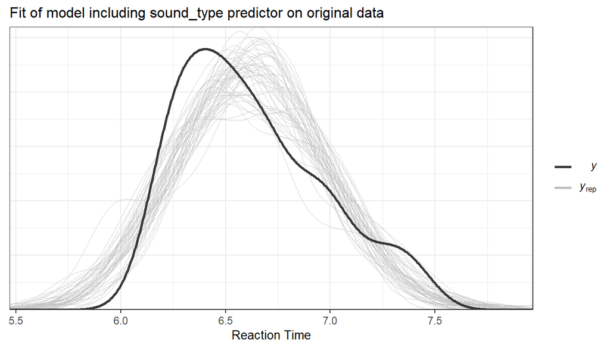

```r
plot_posterior(fit_sound_type, data_cor_resp[data_cor_resp$cue_type == 'sound',]$RT_log, "Fit of model including sound_type predictor on original data")
```

```r
# Now we compare the two conditions of both factors
# First we compare environmental condition with verbal label condition (the two levels of cue_type)
cue_comp <- compare_groups(
  model = fit_cue_type,
  higher = list("cue_type" = "sound"),
  lower = list("cue_type" = "label")
)
cue_comp
## Outcome of comparing groups:
##  * higher:  cue_type:sound
##  * lower:   cue_type:label
## Mean 'higher - lower':  -0.05295
## 95% CI: [ -0.2001 ; 0.07699 ]
## P('higher - lower' > 0):  0.1602

# Second we compare the congruent with the incongruent sound type condition (the two levels of sound_type)
snd_comp <- compare_groups(
  model = fit_sound_type,
  higher = list("sound_type" = "incongruent"),
  lower = list("sound_type" = "congruent")
)
snd_comp
## Outcome of comparing groups:
##  * higher:  sound_type:incongruent
##  * lower:   sound_type:congruent
## Mean 'higher - lower':  0.05182
## 95% CI: [ -0.1732 ; 0.2494 ]
## P('higher - lower' > 0):  0.759
```

The results show:  
1. It is not very likely (16% chance) that the verbal label cue leads to lower reaction times than the environmental sound cue.  
2. It is likely (76% chance) that congruent sounds lead to a lower reaction time than incongruent sounds. Still it is not as likely as expected. A probability of 95% would be desirable in order to reject the null hypothesis that incongruent and congruent sound cues are equally efficient in order to verify categories.  
The result 1 match with our findings about the direction of the effect. Still we have to be critical if the models fit to the data. We can see that there are a lot of deviations of the posterior distribution from the underlying data for both of the models. This means that we can not account for an effect of the two factors on the reaction time, because the models do not fit the underlying data sufficiently. This might also be due to the small amount of participants in the pilot study.

### Exploratory hypothesis - Categories

When plotting the distribution of the reaction times in congruent sound cue trial dependent on categories we can see that there is a slight variation of performance. In some categories we find the sound more appropriate or more easy to recognize (environmental sound in conjunction with picture of a category) than in others. Here we will only examine the congruent sound trials. If it is true that some categories are more easy to recognize, then it is more difficult to say that environmental sound are motivated cues that always refer to a specific instance. Some sounds could just be harder to identify, which does not necessarily mean that incongruent environmental sounds trials are significantly more difficult to verify as same category.

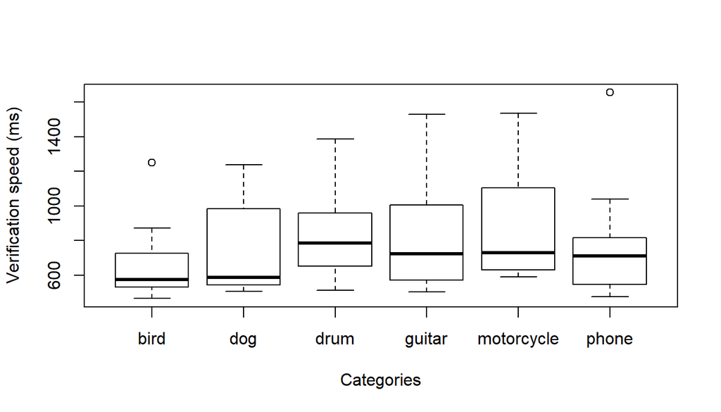

```r
congruent_trials <- data_cor_resp %>% filter(sound_type=="congruent")
categories_plot <- boxplot(RT ~ cue_category, data=congruent_trials, xlab = "Categories", ylab = "Verification speed (ms)")
```

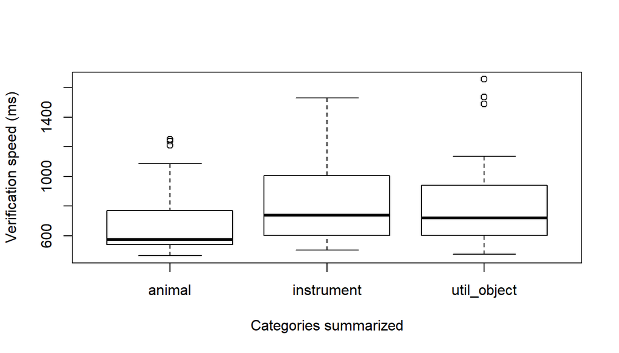

```r
congruent_trials$sum_categories <- ifelse(congruent_trials$cue_category=="dog"|congruent_trials$cue_category=="bird", "animal", ifelse(congruent_trials$cue_category=="guitar"|congruent_trials$cue_category=="drum", "instrument", "util_object"))

# Plot the data with the summarized categories (instruments -> guitar and drum, animals -> dog and bird and utility objects -> phone and motor cycle)
sum_categories_plot <- boxplot(RT ~ sum_categories, data=congruent_trials, xlab = "Categories summarized", ylab = "Verification speed (ms)")
```

We use the bayesian approach to get a more information about the effect of categories on the verification speed in congruent environmental sound trials. We would like to know if there is a systematic effect that yields for all subjects. Explicitly we would like to know if animal sounds lead to faster reaction times than sounds belonging to instruments or utility objects.

Since subjects might be variously familiar with certain categories the model will include a random slope and random intercept effect. The random intercept (by-item) effect is included as well, because we still have unique trial type (like in the models above).

Hence our model looks like this:  
RT ~ category_sum + (1+ category_sum | participantID) + (1|trialID)

```r
category_mod <- brm(RT_log ~ sum_categories + (1+sum_categories|submission_id) + (1|trialID), congruent_trials, control = list(adapt_delta = 0.99), seed=2001)
params_cat <- fixef(category_mod)
params_cat
```

```
##                            Estimate Est.Error       Q2.5     Q97.5
## Intercept                 6.4999335 0.2638810  5.9460555 7.0358461
## sum_categoriesinstrument  0.1557440 0.1462073 -0.1278788 0.4314571
## sum_categoriesutil_object 0.1510596 0.1898228 -0.2043605 0.4803253
```

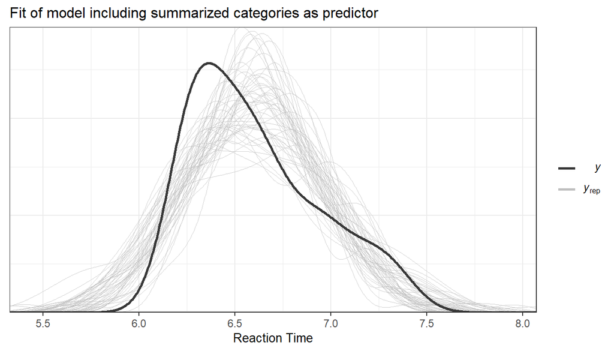

```r
# Plot the posterior distribution
plot_posterior(category_mod, congruent_trials$RT_log, "Fit of model including summarized categories as predictor")
```

```r
anim_instr <- compare_groups(category_mod,
               higher = list("sum_categories" = "instrument"),
               lower = list("sum_categories" = "animal"))

anim_util <- compare_groups(category_mod,
               higher = list("sum_categories" = "animal"),
               lower = list("sum_categories" = "util_object"))

util_instr <- compare_groups(category_mod,
               higher = list("sum_categories" = "util_object"),
               lower = list("sum_categories" = "instrument"))

instr_util <- compare_groups(category_mod,
               higher = list("sum_categories" = "instrument"),
               lower = list("sum_categories" = "util_object"))
```

If we would add more categories to our experimental design this could of course change. Further analysis of the correlation of category and sound type (congruent and incongruent) is conceivable.